# ICE Annina 10x sequencing analysis - Analysis of extended human data (pseudobulk)

Author

Vladyslav Korobeynyk at Jessberger/Robinsonlab, UZH

Published

October 26, 2026

**Note**

**What this script does:** loads the donor-level pseudobulk `SingleCellExperiment` objects of the extended human DLPFC lifespan cohort ([Synapse syn52396927](https://www.synapse.org/Synapse:syn52396927)), in which all excitatory (EN) and all inhibitory (IN) neuron subtypes were summed per donor, donors with ≤ 10 cells of a given class were removed and LINC genes were dropped. For EN, IN and both combined it checks how much expression variance is explained by Age and other covariates, runs a DESeq2 differential expression analysis of Age (controlling for Sex, Ethnicity, Brain_bank and Control status, plus Celltype for the combined analysis), plots the top age-associated genes and runs GSEA against GO Biological Process terms. It mirrors `02_human_Analysis_metacell_Level.qmd`, but every sample here is one donor (true pseudobulk) instead of bootstrapped metacells.

**Important**

DESeq2 size factors (median-of-ratios) normalise for sequencing depth, which absorbs most of the effect of how many cells were summed per donor. The number of cells is therefore not in the model by default. It still influences noise and, because EN/IN are sums of subtypes, subtype composition. If `n_cells` correlates with Age (see the diagnostic plot below), set `include_log_ncells: true` to add `log(n_cells)` as a covariate.

# Setup

```r
options(future.globals.maxSize = 8000 * 1024^2)
suppressMessages({
  library(scater)
  library(dplyr)
  library(ggplot2)
  library(Matrix)
  library(magrittr)
  library(genekitr)
  library(geneset)
  library(DESeq2)
  library(pheatmap)
  library(tidyr)
  library(rrvgo)
})
source(params$helper_functions_path)
source(params$qc_pipeline_functions_path)
dir.create(params$dea_output_dir, recursive = TRUE, showWarnings = FALSE)
dir.create(params$gsea_output_dir, recursive = TRUE, showWarnings = FALSE)

gs = geneset::getGO(org = "human", ont = "bp")
```

# Load data

```r
pseudobulk_sce_EN = readRDS(file.path(params$pseudobulk_dir, "pseudobulk_sce_EN_human_extended.RDS"))
pseudobulk_sce_IN = readRDS(file.path(params$pseudobulk_dir, "pseudobulk_sce_IN_human_extended.RDS"))
```

# Helper functions for this script

```r
model_covariates = c("Sex", "Ethnicity", "Brain_bank", "Control")

#' Prepare a pseudobulk SCE for DESeq2: age filter, factor covariates, drop donors with
#' missing covariates, log-normalise (needed for getVarianceExplained)
prepare_pseudobulk_sce = function(sce, covariates, min_age, max_age) {
  n_start = ncol(sce)

  sce$Age = as.numeric(sce$Age)
  sce = sce[, !is.na(sce$Age) & sce$Age >= min_age & sce$Age < max_age]

  # DESeq2 cannot handle NA in design variables
  complete = Reduce(`&`, lapply(covariates, function(v) !is.na(colData(sce)[[v]])))
  sce = sce[, complete]

  for (v in covariates) colData(sce)[[v]] = droplevels(factor(colData(sce)[[v]]))
  sce$log_n_cells = log(sce$n_cells)

  # metacell_DESeq2_DEA() annotates its correlation heatmap with Diagnosis and
  # Sample_Source; here Diagnosis = Control status, Sample_Source = Brain_bank
  sce$Diagnosis = sce$Control
  sce$Sample_Source = sce$Brain_bank

  sce = sce[rowSums(counts(sce)) > 0, ]

  # DESeq2 expects a dense integer count matrix
  counts_dense = as.matrix(counts(sce))
  stopifnot(all(counts_dense == round(counts_dense)))
  storage.mode(counts_dense) = "integer"
  counts(sce) = counts_dense

  sce = logNormCounts(sce)

  message(sprintf("%s: %d -> %d donors (age %g-%g, complete covariates)",
                  paste(unique(sce$Celltype), collapse = "|"), n_start, ncol(sce), min_age, max_age))
  sce
}

#' Build the DESeq2 design formula; Age is always the last term
build_design = function(covariates, include_log_ncells) {
  terms = c(covariates, if (include_log_ncells) "log_n_cells", "Age")
  as.formula(paste("~", paste(terms, collapse = " + ")))
}

#' Variance-explained diagnostics + donor-level DESeq2 DEA of Age, save markers, plot MA
run_pseudobulk_dea = function(sce, design_formula, markers_csv_path, variance_vars) {

  # variance-explained diagnostic on donors with no missing value in these variables
  variance_df = as.data.frame(colData(sce))[, variance_vars, drop = FALSE]
  keep = stats::complete.cases(variance_df)
  getVarianceExplained(sce[, keep], variables = variance_df[keep, , drop = FALSE]) %>%
    plotExplanatoryVariables() %>%
    print()

  DESeq2_lst = metacell_DESeq2_DEA(
    sce = sce, phenotype_column = "Age", dataset_column = "Brain_bank",
    design_formula = design_formula, contrast = "Age", organism = "human"
  )

  print(DESeq2_lst$plt_phenotype)
  print(DESeq2_lst$plt_dataset)
  print(DESeq2_lst$heatmap)

  markers = DESeq2_lst$markers %>% filter(if_all(everything(), ~ !is.na(.)))
  write.csv(markers, markers_csv_path)

  DESeq2::plotMA(DESeq2_lst$res)

  list(markers = markers, DESeq2_lst = DESeq2_lst)
}

#' Plot VST-normalized expression vs Age for the top up/down DEA genes,
#' colored by each covariate in color_by_vars (one plot per covariate)
plot_top_age_genes = function(markers, DESeq2_lst, color_by_vars, n_top_genes) {

  top_down = markers %>% arrange(avg_log2FC) %>% dplyr::slice(1:n_top_genes) %>% pull(gene)
  top_up   = markers %>% arrange(desc(avg_log2FC)) %>% dplyr::slice(1:n_top_genes) %>% pull(gene)
  genes = c(top_down, top_up)

  expr = assay(DESeq2_lst$vst_transformed_deseq2)  # genes x samples
  dds  = DESeq2_lst$dds

  df = expr[genes, , drop = FALSE] %>%
    as.data.frame() %>%
    tibble::rownames_to_column("gene") %>%
    pivot_longer(-gene, names_to = "sample", values_to = "expression") %>%
    left_join(
      as.data.frame(colData(dds)) %>% tibble::rownames_to_column("sample"),
      by = "sample"
    )

  for (covariate in color_by_vars) {
    p = ggplot(df, aes(x = Age, y = expression, color = .data[[covariate]])) +
      geom_point(size = 1.5, alpha = 0.6) +
      facet_wrap(~ gene, scales = "free_y") +
      theme_minimal() +
      labs(y = "VST normalized expression") +
      ggtitle(paste0(n_top_genes, " down / ", n_top_genes,
                     " up genes changing with age, colored by ", covariate))
    print(p)
  }
}

#' Run GSEA on a saved DEA markers table, save results, generate reduced-GO treemaps
run_gsea_workflow = function(markers_csv_path, gs, n_pathways, title_label,
                             gsea_rds_path, neg_txt_path, pos_txt_path) {

  markers = read.csv(markers_csv_path, row.names = 1)
  gsea = gsea_analysis(markers = markers, cluster = "trending clusters", gs = gs,
                       n_pathways = n_pathways, plot_type = "bar")

  if (is.list(gsea)) {
    saveRDS(gsea, gsea_rds_path)
    lst = plot_ReducedGOterms(gsea_df = gsea$gsea_df, title_label = title_label)
    write.table(lst$neg, neg_txt_path, row.names = FALSE, quote = FALSE)
    write.table(lst$pos, pos_txt_path, row.names = FALSE, quote = FALSE)
  }

  gsea
}
```

# Data preparation

```r
pseudobulk_sce_EN = prepare_pseudobulk_sce(pseudobulk_sce_EN, model_covariates, params$min_age, params$max_age)
pseudobulk_sce_IN = prepare_pseudobulk_sce(pseudobulk_sce_IN, model_covariates, params$min_age, params$max_age)

design_formula = build_design(model_covariates, params$include_log_ncells)
design_formula_merged = build_design(c(model_covariates, "Celltype"), params$include_log_ncells)
design_formula
```

```
~Sex + Ethnicity + Brain_bank + Control + log_n_cells + Age
<environment: 0x5f9d83507208>
```

```r
variance_vars = c("Age", "PMI", "Sex", "Ethnicity", "Brain_bank", "Control", "log_n_cells") # only for diagnostic plots
```

## Donors and covariates

```r
donor_df = rbind(
  as.data.frame(colData(pseudobulk_sce_EN))[, c("Individual_ID", "Celltype", "Age", "n_cells", "lib_size")],
  as.data.frame(colData(pseudobulk_sce_IN))[, c("Individual_ID", "Celltype", "Age", "n_cells", "lib_size")]
)

table(Celltype = donor_df$Celltype)
```

```
Celltype
 EN  IN
165 165
```

```r
lapply(model_covariates, function(v) table(colData(pseudobulk_sce_EN)[[v]], useNA = "ifany")) %>%
  setNames(model_covariates)
```

```
$Sex

Female   Male
    43    122

$Ethnicity

AFR AMR EAS EUR SAS
 55  19   2  88   1

$Brain_bank

HBCC MSSM
  83   82

$Control

  0   1
 28 137
```

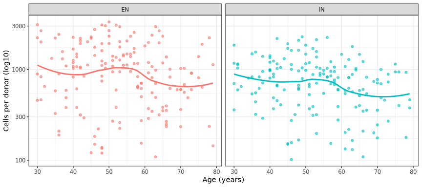

```r
# does the number of summed cells change with age? if so, consider include_log_ncells: true
ggplot(donor_df, aes(x = Age, y = n_cells, colour = Celltype)) +
  geom_point(alpha = 0.6) +
  geom_smooth(method = "loess", se = FALSE) +
  scale_y_log10() +
  facet_wrap(~ Celltype) +
  labs(x = "Age (years)", y = "Cells per donor (log10)") +
  theme_bw() + theme(legend.position = "none")
```

```r
sapply(split(donor_df, donor_df$Celltype), function(d) cor(d$Age, log(d$n_cells), method = "spearman"))
```

```
        EN         IN
-0.1811224 -0.2401000
```

# Var explained / DEA

**Here we are trying to understand if Age is a variable that can explain the variability in the data**

**IN**

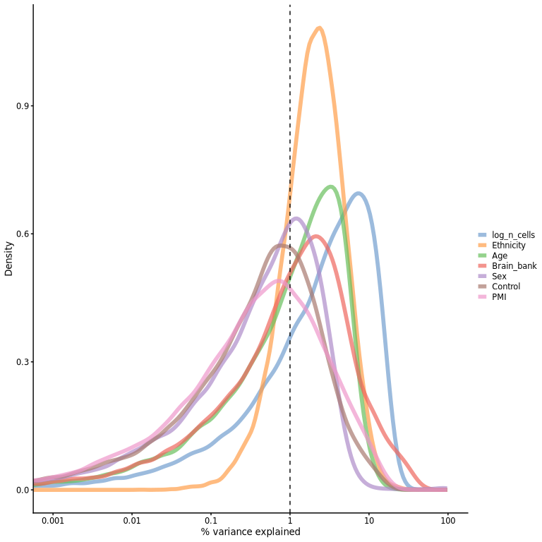

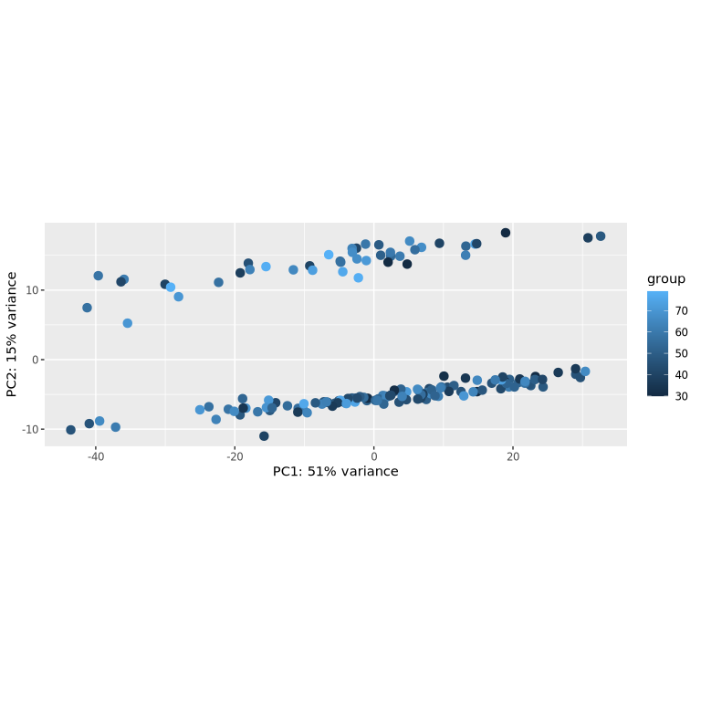

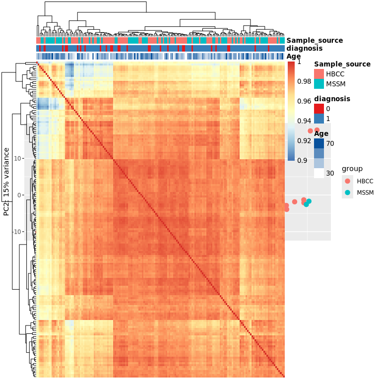

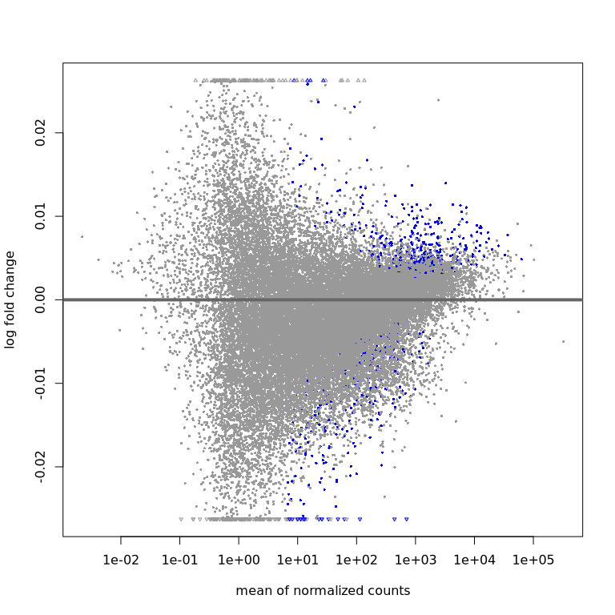

```r
dea_IN = run_pseudobulk_dea(
  sce = pseudobulk_sce_IN,
  design_formula = design_formula,
  markers_csv_path = file.path(params$dea_output_dir, "DEA_pseudobulk_iN_age_human_extended.csv"),
  variance_vars = variance_vars
)
```

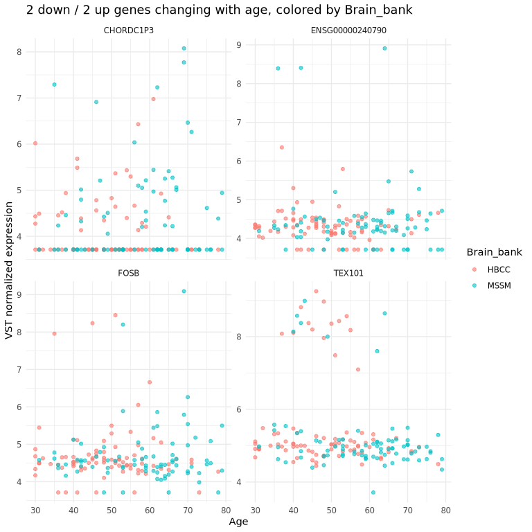

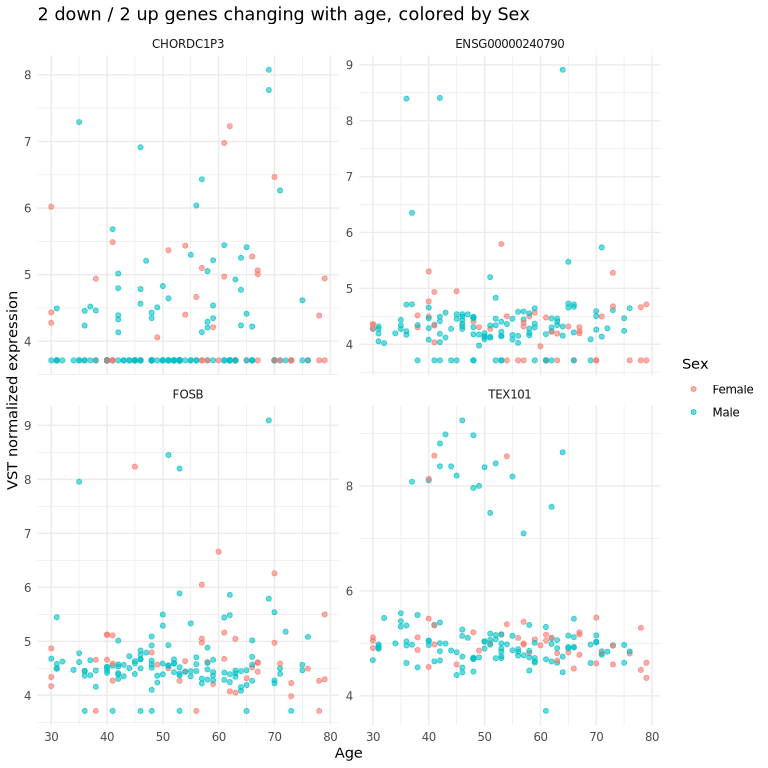

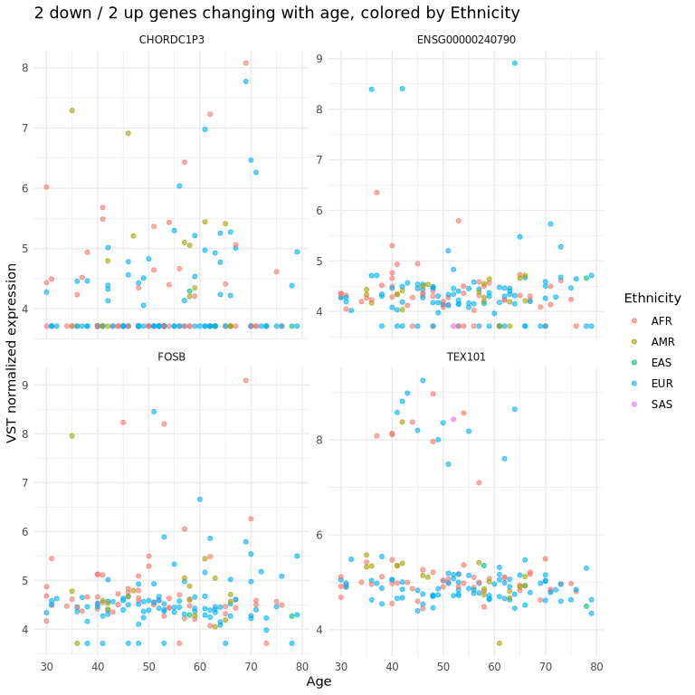

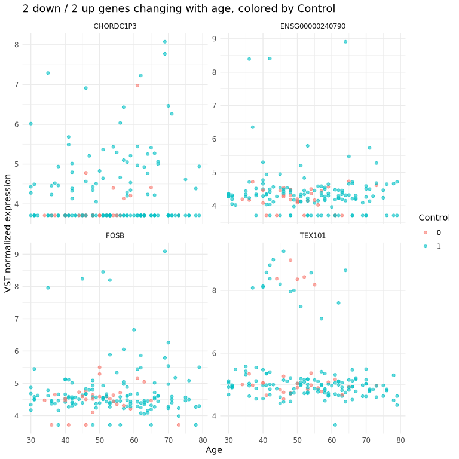

```r
plot_top_age_genes(
  markers = dea_IN$markers, DESeq2_lst = dea_IN$DESeq2_lst,
  color_by_vars = c("Brain_bank", "Sex", "Ethnicity", "Control"),
  n_top_genes = params$n_top_genes_per_direction
)
```

**EN**

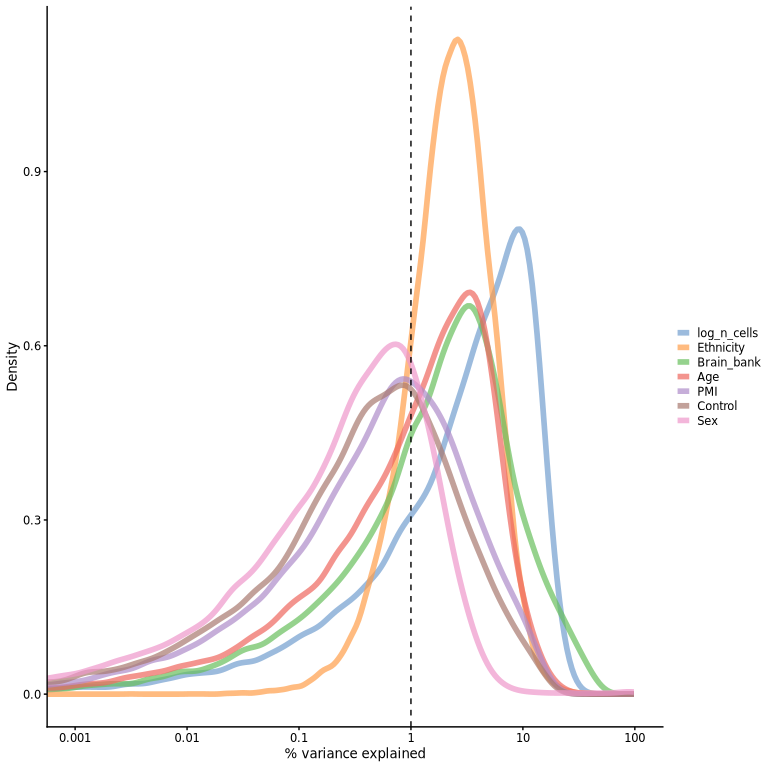

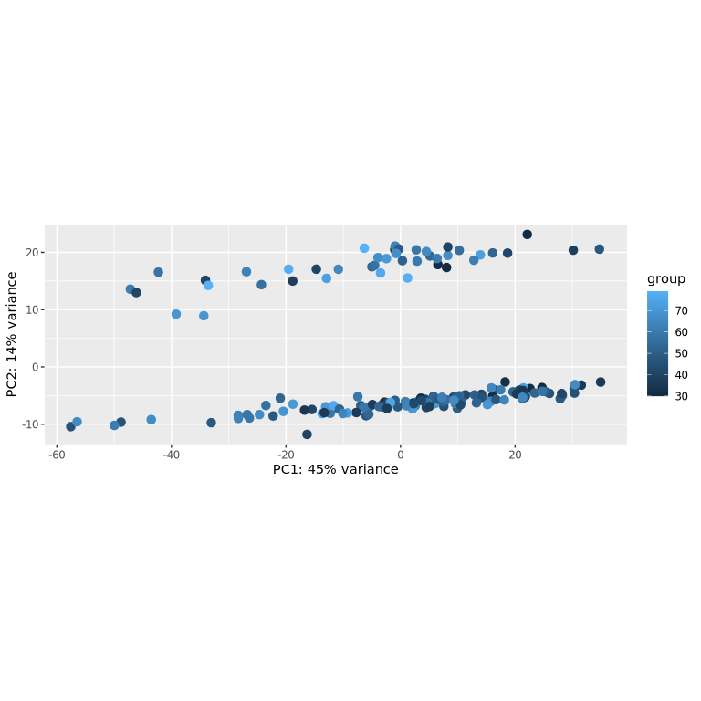

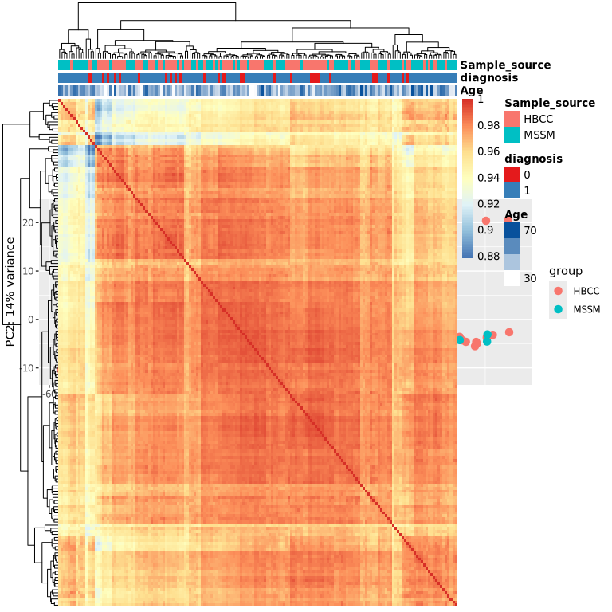

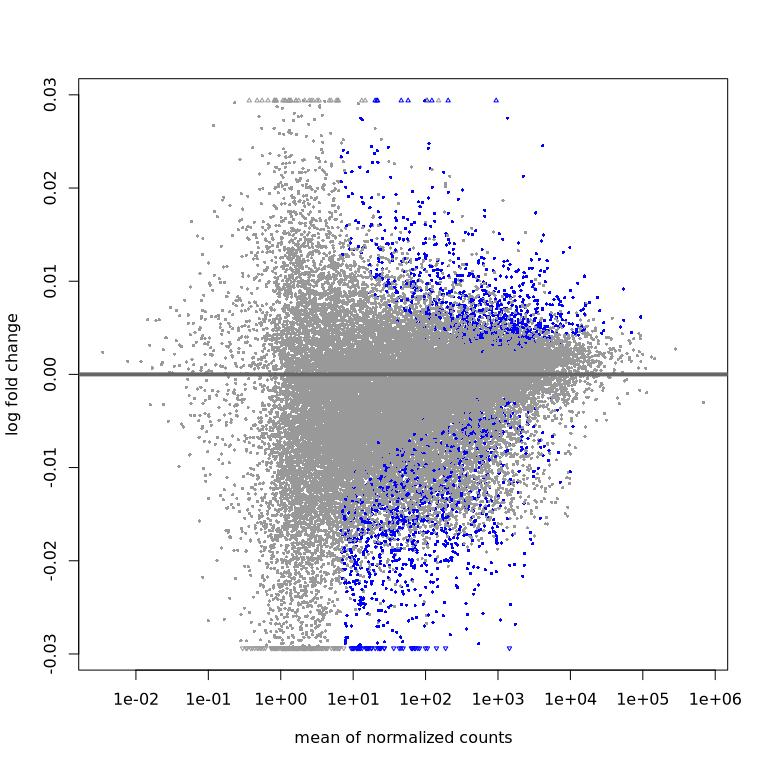

```r
dea_EN = run_pseudobulk_dea(
  sce = pseudobulk_sce_EN,
  design_formula = design_formula,
  markers_csv_path = file.path(params$dea_output_dir, "DEA_pseudobulk_exN_age_human_extended.csv"),
  variance_vars = variance_vars
)
```

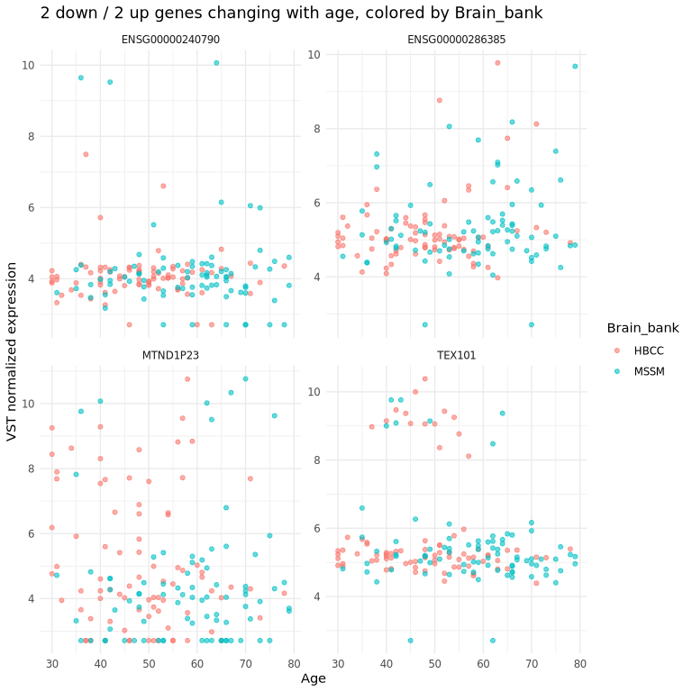

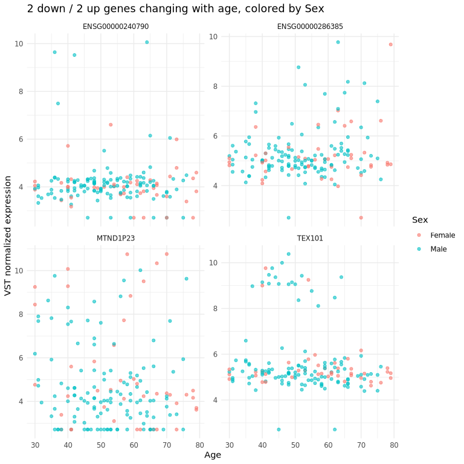

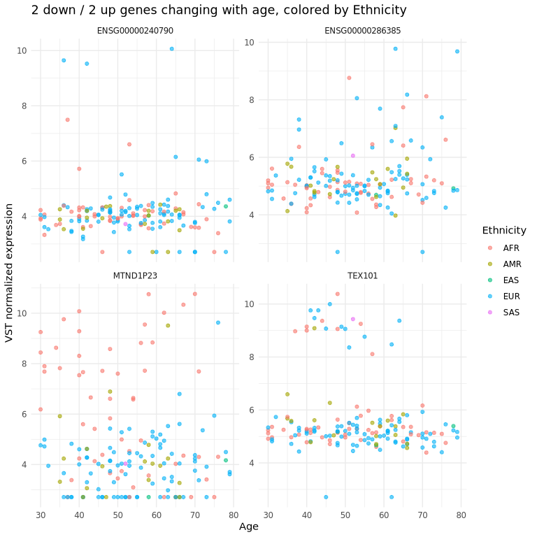

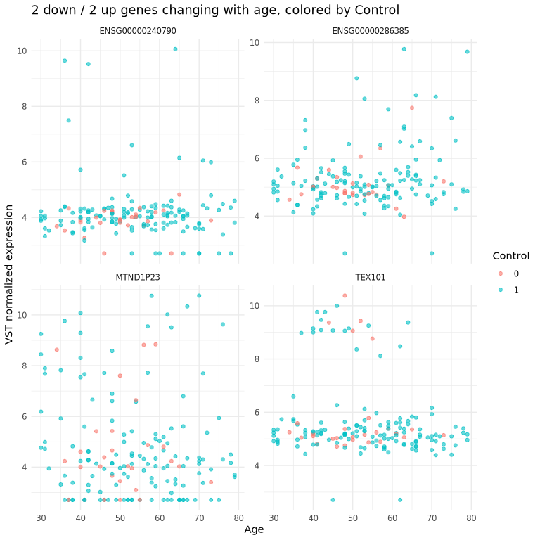

```r
plot_top_age_genes(
  markers = dea_EN$markers, DESeq2_lst = dea_EN$DESeq2_lst,
  color_by_vars = c("Brain_bank", "Sex", "Ethnicity", "Control"),
  n_top_genes = params$n_top_genes_per_direction
)
```

**IN | EN**

Merge both cell types and perform the same analysis, with Celltype as an extra covariate. Each donor contributes up to two samples (IN and EN).

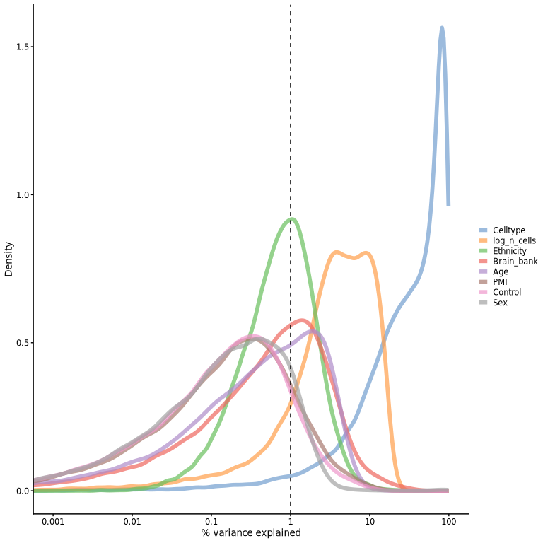

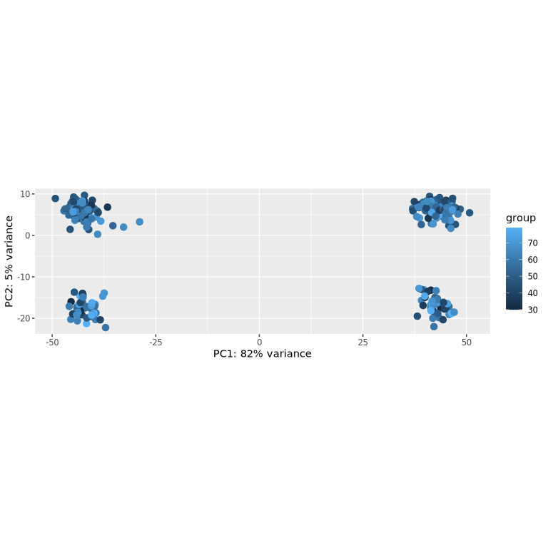

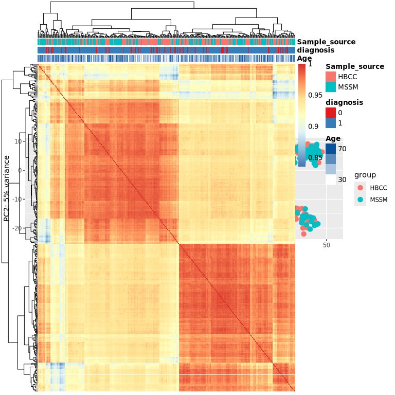

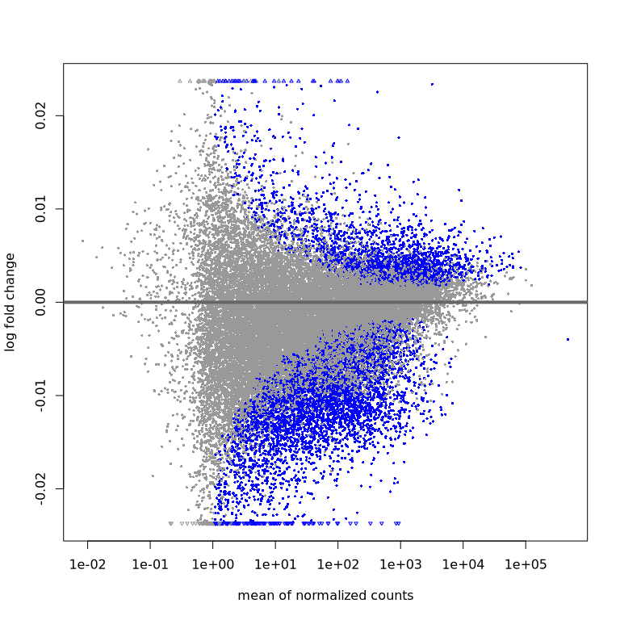

```r
# prefix donor IDs so IN/EN samples don't collide, restrict to shared genes/colData
sce_IN_for_merge = pseudobulk_sce_IN
sce_EN_for_merge = pseudobulk_sce_EN
colnames(sce_IN_for_merge) = paste0("IN_", colnames(sce_IN_for_merge))
colnames(sce_EN_for_merge) = paste0("EN_", colnames(sce_EN_for_merge))

common_genes = intersect(rownames(sce_IN_for_merge), rownames(sce_EN_for_merge))
sce_IN_for_merge = sce_IN_for_merge[common_genes, ]
sce_EN_for_merge = sce_EN_for_merge[common_genes, ]

common_cols = intersect(names(colData(sce_IN_for_merge)), names(colData(sce_EN_for_merge)))
colData(sce_IN_for_merge) = colData(sce_IN_for_merge)[, common_cols, drop = FALSE]
colData(sce_EN_for_merge) = colData(sce_EN_for_merge)[, common_cols, drop = FALSE]

# keep only counts; logcounts are recomputed on the merged object
assays(sce_IN_for_merge) = assays(sce_IN_for_merge)["counts"]
assays(sce_EN_for_merge) = assays(sce_EN_for_merge)["counts"]
rowData(sce_IN_for_merge) = NULL
rowData(sce_EN_for_merge) = NULL

merged_pseudobulk_sce = cbind(sce_IN_for_merge, sce_EN_for_merge)
merged_pseudobulk_sce$Celltype = factor(merged_pseudobulk_sce$Celltype)
merged_pseudobulk_sce = logNormCounts(merged_pseudobulk_sce)

dea_merged = run_pseudobulk_dea(
  sce = merged_pseudobulk_sce,
  design_formula = design_formula_merged,
  markers_csv_path = file.path(params$dea_output_dir, "DEA_pseudobulk_neurons_age_human_extended.csv"),
  variance_vars = c(variance_vars, "Celltype")
)
```

# GSEA

**IN**

```
preparing gene to GO mapping data...
```

```
preparing IC data...
```

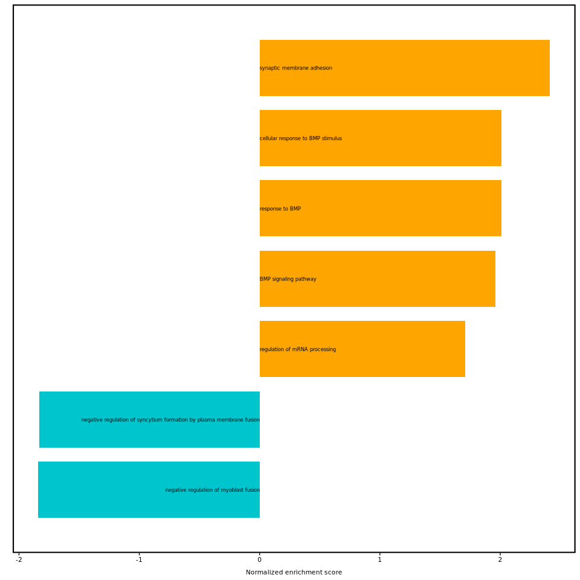

```
preparing gene to GO mapping data...
```

```
preparing IC data...
```

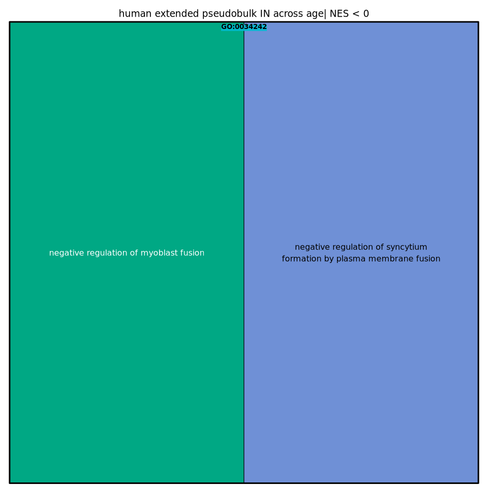

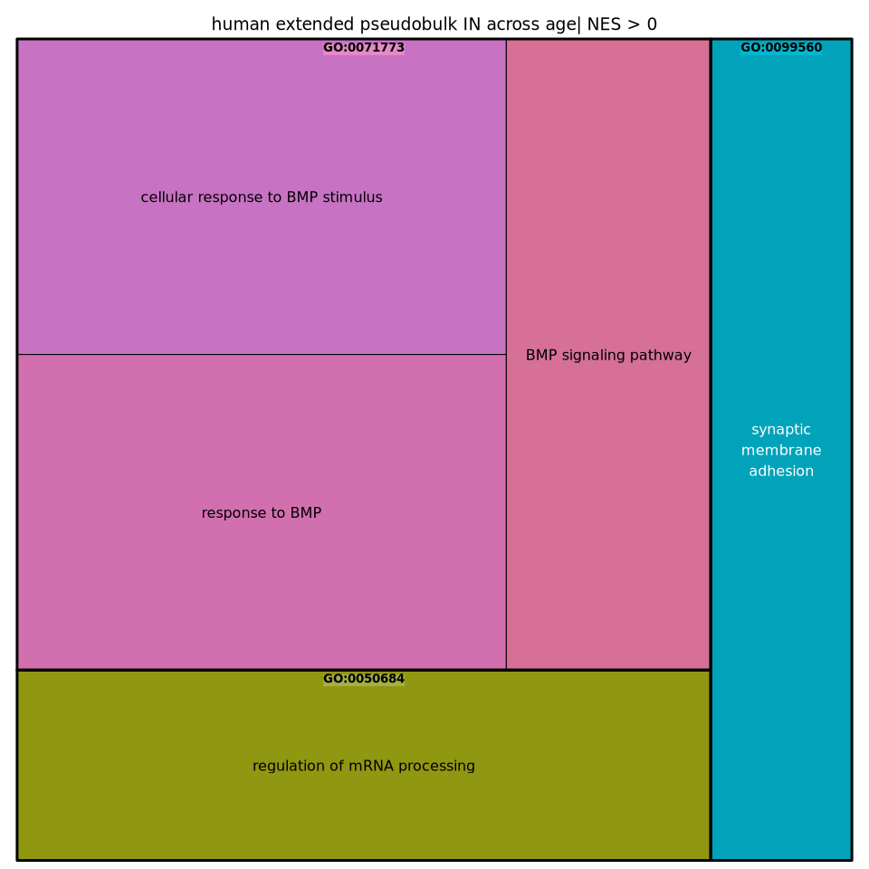

```r
gsea_IN = run_gsea_workflow(
  markers_csv_path = file.path(params$dea_output_dir, "DEA_pseudobulk_iN_age_human_extended.csv"),
  gs = gs,
  n_pathways = params$n_gsea_pathways,
  title_label = "human extended pseudobulk IN across age",
  gsea_rds_path = file.path(params$gsea_output_dir, "GOterms_pseudobulk_age_iN_all_human_extended.RDS"),
  neg_txt_path = file.path(params$gsea_output_dir, "GOterms_pseudobulk_age_iN_downregulated_old_human_extended.txt"),
  pos_txt_path = file.path(params$gsea_output_dir, "GOterms_pseudobulk_age_iN_upregulated_old_human_extended.txt")
)
```

**EN**

```
preparing gene to GO mapping data...
```

```
preparing IC data...
```

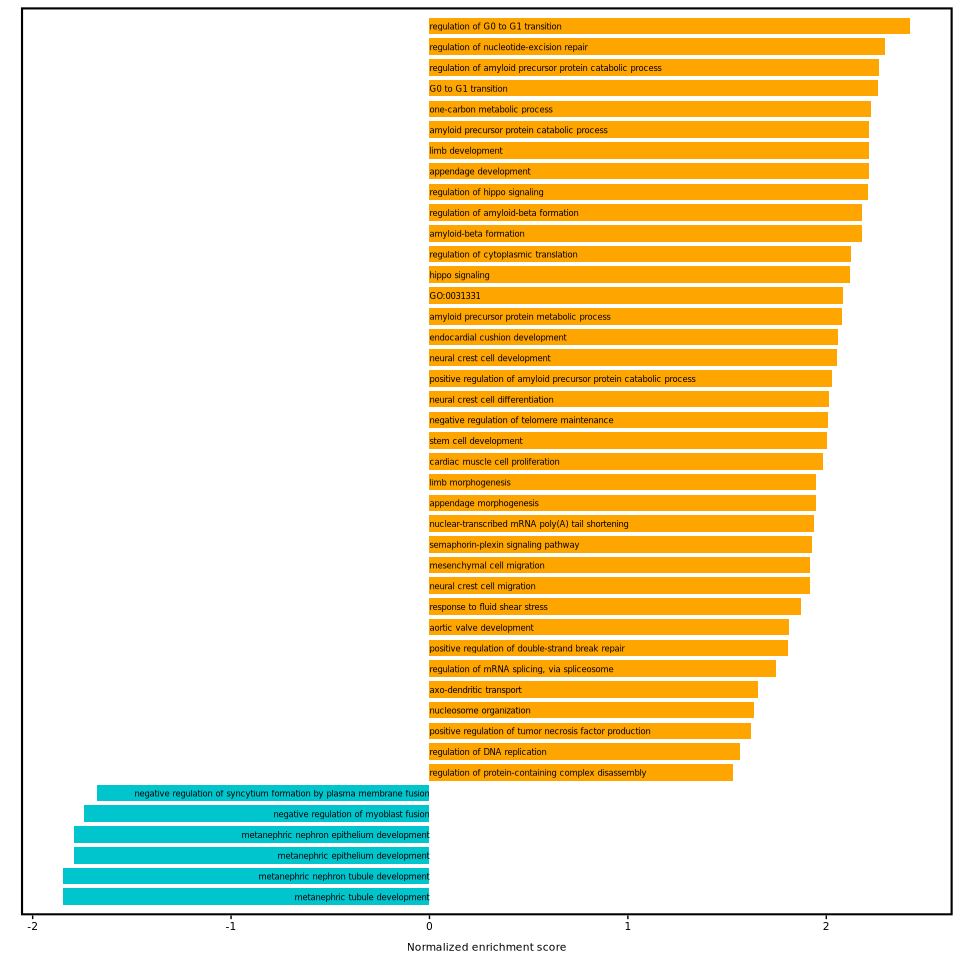

```
preparing gene to GO mapping data...
```

```
preparing IC data...
```

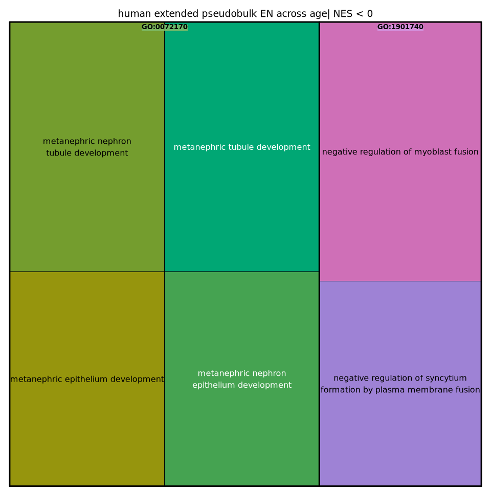

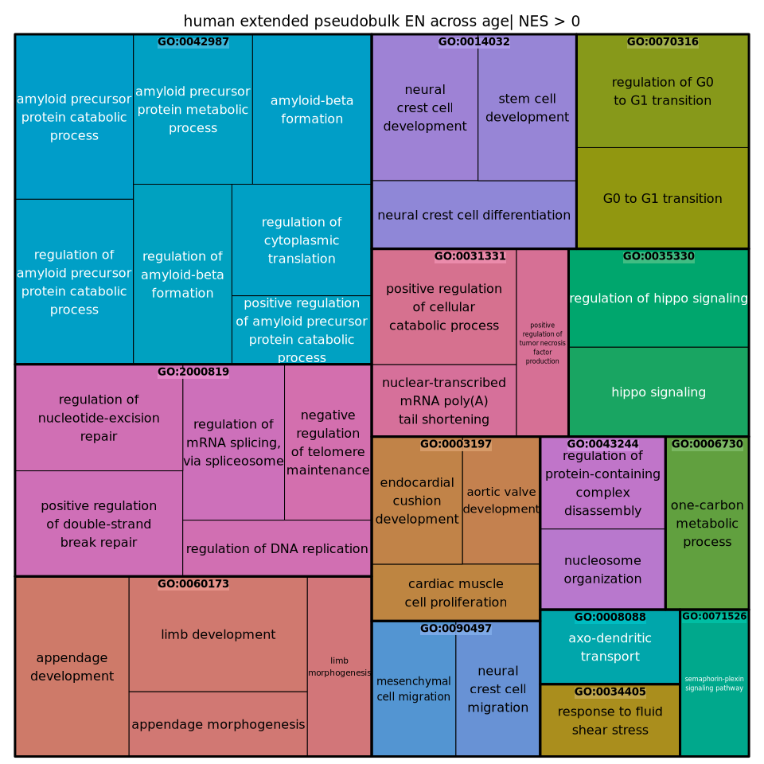

```r
gsea_EN = run_gsea_workflow(
  markers_csv_path = file.path(params$dea_output_dir, "DEA_pseudobulk_exN_age_human_extended.csv"),
  gs = gs,
  n_pathways = params$n_gsea_pathways,
  title_label = "human extended pseudobulk EN across age",
  gsea_rds_path = file.path(params$gsea_output_dir, "GOterms_pseudobulk_age_exN_all_human_extended.RDS"),
  neg_txt_path = file.path(params$gsea_output_dir, "GOterms_pseudobulk_age_exN_downregulated_old_human_extended.txt"),
  pos_txt_path = file.path(params$gsea_output_dir, "GOterms_pseudobulk_age_exN_upregulated_old_human_extended.txt")
)
```

**IN | EN**

```r
gsea_merged = run_gsea_workflow(
  markers_csv_path = file.path(params$dea_output_dir, "DEA_pseudobulk_neurons_age_human_extended.csv"),
  gs = gs,
  n_pathways = params$n_gsea_pathways,
  title_label = "human extended pseudobulk IN|EN across age",
  gsea_rds_path = file.path(params$gsea_output_dir, "GOterms_pseudobulk_age_neurons_all_human_extended.RDS"),
  neg_txt_path = file.path(params$gsea_output_dir, "GOterms_pseudobulk_age_neurons_downregulated_old_human_extended.txt"),
  pos_txt_path = file.path(params$gsea_output_dir, "GOterms_pseudobulk_age_neurons_upregulated_old_human_extended.txt")
)
```

```
no term enriched under specific pvalueCutoff...
```